# 3. Results Analysis and Visualization

gDR team

2026-06-16

3. Results Analysis and Visualization

**gDR Analysis Pipeline**

Date: 2026-06-16

Author: [gDR team](https://github.com/gdrplatform)

# 1 Introduction

This report concludes the gDR analysis pipeline by presenting the final results in user-friendly formats. Starting with the processed `MultiAssayExperiment` object from Step 2, this report first exports all data into Excel files. It then generates a series of visualizations designed for biological interpretation, including dose-response curves and summary heatmaps of the calculated drug sensitivity metrics.

```r
library(qs2)
library(purrr)
library(SummarizedExperiment)
library(data.table)
library(writexl)
library(gDRutils)
library(gDRplots)
library(ggplot2)
```

# 2 Key Output Files

This report generates the **`tables`** folder, which contains the final, user-friendly Excel files for all processed data and visualization data.

## 2.1 Main Assay Reports (in `tables/` folder)

These files contain the full processed data in a “long” (tidy) format, with one Excel file per experiment type (e.g., `single-agent-assay-data.xlsx`, `combo-assay-data.xlsx`). Each file contains multiple sheets:

- **`Averaged`:** The normalized dose-response data, averaged across technical replicates.
- **Key columns:** `Concentration`, `x`, and `x_std`. The `x` column represents the mean normalized response, and `x_std` is its standard deviation. The meaning of these values (Relative Viability or GR value) is defined by the `normalization_type` column in the same row.
- **`Metrics`:** The final calculated drug-response parameters. The meaning of all metrics prefixed with `x_` (e.g., `xc50`, `x_mean`) is dependent on the `normalization_type` column (e.g., “RV” or “GR”) in the same row.
- **Key columns:**
- `x_mean`: The mean normalized response across all concentrations (excluding controls).
- `x_AOC`: The Area Over the Curve, averaged over the full concentration range.
- `x_AOC_range`: The Area Over the Curve, calculated only within the tested concentration range.
- `xc50`: The concentration (e.g., IC50 or GR50) at which the response reaches 0.5.
- `x_max`: The maximum effect of the drug (Emax).
- `ec50`: The drug concentration at half-maximal effect.
- `x_inf`: The asymptotic response as concentration goes to infinity (bottom asymptote).
- `x_0`: The asymptotic response at zero concentration (top asymptote).
- `h`: The Hill slope, reflecting the steepness of the curve.
- `r2`: R-squared, indicating the goodness-of-fit.
- `p_value`: The p-value associated with the model fit.
- `rss`: Residual sum of squares, a measure of model error.
- `x_sd_avg`: The average standard deviation of the normalized response values.
- `fit_type`: The status of the curve fit (e.g., “DRC4pHillFitModel” for a successful 4-parameter fit, “DRCConstantFitResult” for a flat fit, or “DRCInvalidFitResult” for a failed fit).
- `maxlog10Concentration`: The highest log10 concentration tested.
- `N_conc`: The number of unique concentrations used in the fit.
- `cotrt_value` (combo only): The concentration of the fixed co-drug in a dose-response series.
- `ratio` (combo only): The concentration ratio between the two drugs in a series.
- `dilution_drug` (combo only): Indicates which drug was diluted in the series (e.g., “drug_1”, “drug_2”, or “codilution”).
- **`excess` (combo only):** Contains the calculated “excess” response (synergy/antagonism) at *every* dose combination, which is the basis for the final summary scores.
- **Key columns:** `smooth` (the model-smoothed normalized response value), `hsa_excess` (the calculated synergy/antagonism score using the HSA model), and `bliss_excess` (the synergy/antagonism score using the Bliss model). The `normalization_type` column indicates if these values are based on “RV” or “GR” data.
- **`all_iso_points` (combo only):** The complete dataset of fitted points from the dose-response surface used to calculate the isobolograms.
- **Key columns:**
- `iso_level`: The effect level (e.g., 0.25, 0.5, 0.75).
- `conc_1`, `conc_2`: The concentrations of drug 1 and drug 2 that produce the given effect level.
- `pos_x`, `pos_y`: The x/y coordinates of this point on the (log-transformed) dose-response surface.
- `fit_type`: The source of the fit (`by_row`, `by_col`, or `by_codil`).
- `scores` (combo only): The single-value summary scores that quantify the overall synergistic or antagonistic effect for each drug combination.
- **Key columns:**
- `hsa_score`: Synergy score based on the Highest Single Agent (HSA) model. A positive score indicates the combination is more effective than its most active single drug.
- `bliss_score`: Synergy score based on the Bliss Independence model. A positive score indicates the combination is more effective than expected if the drugs acted independently.
- `CIScore_50`: Combination Index (CI) score at 50% effect. A value < 1 indicates synergy.
- `CIScore_80`: Combination Index (CI) score at 80% effect. A value < 1 indicates synergy.
- `normalization_type`: Indicates if these scores are based on “RV” or “GR” data.
- **`isobolograms` (combo only):** The data points used to draw the final isobole lines (contours of equal effect) and the Combination Index plots.
- **Key columns:**
- `iso_level`: The effect level being plotted (e.g., 0.5 for 50% effect).
- `pos_x`, `pos_y`: The coordinates for the *measured* isobole line (solid line on the heatmap).
- `pos_x_ref`, `pos_y_ref`: The coordinates for the *theoretical additivity* line (dashed line on the heatmap).
- `log10_ratio_conc`: The log10 of the concentration ratio, used as the x-axis for the CI plot.
- `log2_CI`: The log2 of the Combination Index, used as the y-axis for the CI plot (where 0 = additivity).

## 2.2 Heatmap Data (in `tables/` folder)

These files contain the specific data used to generate the summary heatmaps, pre-formatted for convenience. Each Excel file (e.g., `data__sa_fit_heat_RV__log10(IC50).xlsx` or `data__combo_fit_...xlsx`) contains three sheets:

- **`matrix`:** The wide-format data matrix. The first column lists the rows (e.g., Drugs or Drug Combinations), the first row lists the columns (e.g., Cell Lines), and the cells contain the metric values.
- **`annotation_col`:** A table of metadata for the columns of the `matrix` sheet (e.g., cell line tissue type).
- **`annotation_row`:** A table of metadata for the rows of the `matrix` sheet (e.g., drug MOA).

# 3 Read the gDR MAE data

This section loads the final `MultiAssayExperiment` (MAE) object, which contains all the processed data and results from the previous step.

```r
wd <- getwd()
dir.create(file.path(wd, "plots"), showWarnings = FALSE, recursive = TRUE)
dir.create(file.path(wd, "gDR_data"), showWarnings = FALSE, recursive = TRUE)
dir.create(file.path(wd, "tables"), showWarnings = FALSE, recursive = TRUE)
mae <- qs_read(file.path(wd, "gDR_data", "gDR_mae.qs2"))
```

# 4 Split SE objects into list of assays and save as an XLSX file

For convenience and for sharing with non-R users, all processed data assays (Averaged, Metrics, etc.) are extracted from the MAE object and saved as multi-sheet Excel files. One file is created for each experiment type (e.g., single-agent, combo).

```r
assay_list <- MAEpply(mae, function(x) {
  lst <- lapply(setdiff(assayNames(x), c("RawTreated", "Controls", "Normalized")),
                function(y) convert_se_assay_to_dt(x, y,
                                                   unify_metadata = TRUE,
                                                   merge_additional_variables = TRUE))
  names(lst) <- setdiff(assayNames(x), c("RawTreated", "Controls", "Normalized"))
  lst
})
```

```r
assay_list_to_save <- lapply(assay_list, split_big_table_for_xlsx)
for (experiment in names(assay_list_to_save)) {
  write_xlsx(assay_list_to_save[[experiment]], file.path(wd, "tables",
                                                         paste0(experiment,
                                                                "-assay-data.xlsx")))
}
```

# 5 Downstream data analysis

This section prepares the final data for plotting and generates a series of visualizations for biological interpretation of the results.

```r
sa_name <- get_supported_experiments("sa")

response_data_sa <- assay_list[[sa_name]][["Averaged"]]
response_metrics_sa <- assay_list[[sa_name]][["Metrics"]]
response_metrics_sa_capped <-
  cap_assay_infinities(conc_assay_dt = response_data_sa,
                       assay_dt = response_metrics_sa,
                       experiment_name = sa_name,
                       col = "xc50",
                       capping_fold = 5)
```

```r
combo_name <- get_supported_experiments("combo")

response_metrics_combo <- assay_list[[combo_name]][["Metrics"]]
response_data_combo <- assay_list[[combo_name]][["Averaged"]]
response_metrics_excess <- assay_list[[combo_name]][["excess"]]
response_metrics_isobolograms <- assay_list[[combo_name]][["isobolograms"]]
response_metrics_scores <- assay_list[[combo_name]][["scores"]]
response_metrics_combo_capped <-
  cap_assay_infinities(conc_assay_dt = response_data_combo,
                       assay_dt = response_metrics_combo,
                       experiment_name = combo_name,
                       col = "xc50",
                       capping_fold = 5)
```

## 5.1 Data Analysis - Dose-response Curves by Drugs - Single-Agent Data

In this view, each plot displays a single **drug** tested across all **cell lines**. This format is ideal for quickly identifying which cell lines are sensitive or resistant to a specific drug.

**What to look for:** Look for curves that shift to the left (indicating higher potency) or have a lower plateau (indicating greater efficacy) in certain cell lines.

```r
cellline_name_vec <- sort(unique(response_metrics_sa[["CellLineName"]]))
drug_name_vec <- sort(unique(response_metrics_sa[["DrugName"]]))

if (TRUE) {
  ls_curv_RV <- plot_dose_response_sa_by_CLs(dt_metrics = response_metrics_sa,
                                             dt_average = response_data_sa,
                                             cellline_name_vec = cellline_name_vec,
                                             drug_name_vec = drug_name_vec,
                                             normalization_type = "RV")
  names(ls_curv_RV) <- vapply(names(ls_curv_RV), function(i) escape_special_characters(i),
                              FUN.VALUE = character(1), USE.NAMES = FALSE)
} else {
  ls_heat_d_RV <- lapply(drug_name_vec, function(nm) {
    pheatmap_qc(dt_average = response_data_sa[DrugName == nm],
                normalization_type = "RV",
                lbl_by_CellLineName = TRUE,
                lbl_by_DrugName = TRUE,
                cluster_rows = TRUE)
  })
  names(ls_heat_d_RV) <- vapply(drug_name_vec, function(i) escape_special_characters(i),
                                FUN.VALUE = character(1), USE.NAMES = FALSE)
}
```

```r
if (TRUE) {
  ls_curv_GR <- plot_dose_response_sa_by_CLs(dt_metrics = response_metrics_sa,
                                             dt_average = response_data_sa,
                                             cellline_name_vec = cellline_name_vec,
                                             drug_name_vec = drug_name_vec,
                                             normalization_type = "GR")
  names(ls_curv_GR) <- vapply(names(ls_curv_GR), function(i) escape_special_characters(i),
                              FUN.VALUE = character(1), USE.NAMES = FALSE)
} else {
  ls_heat_d_GR <- lapply(drug_name_vec, function(nm) {
    pheatmap_qc(dt_average = response_data_sa[DrugName == nm],
                normalization_type = "GR",
                lbl_by_CellLineName = TRUE,
                lbl_by_DrugName = TRUE,
                cluster_rows = TRUE)
  })
  names(ls_heat_d_GR) <- vapply(drug_name_vec, function(i) escape_special_characters(i),
                                FUN.VALUE = character(1), USE.NAMES = FALSE)
}
```

### 5.1.1 Relative Viability

#### 5.1.1.1 Everolimus

🔍 Zoom In for Details

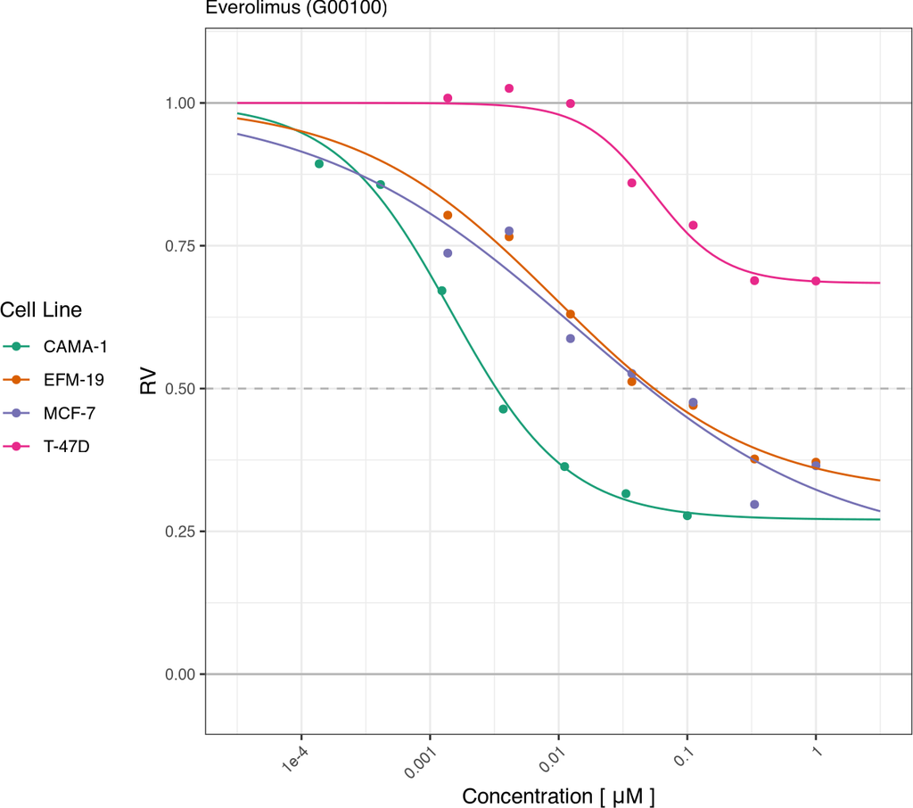

#### 5.1.1.2 Giredestrant

🔍 Zoom In for Details

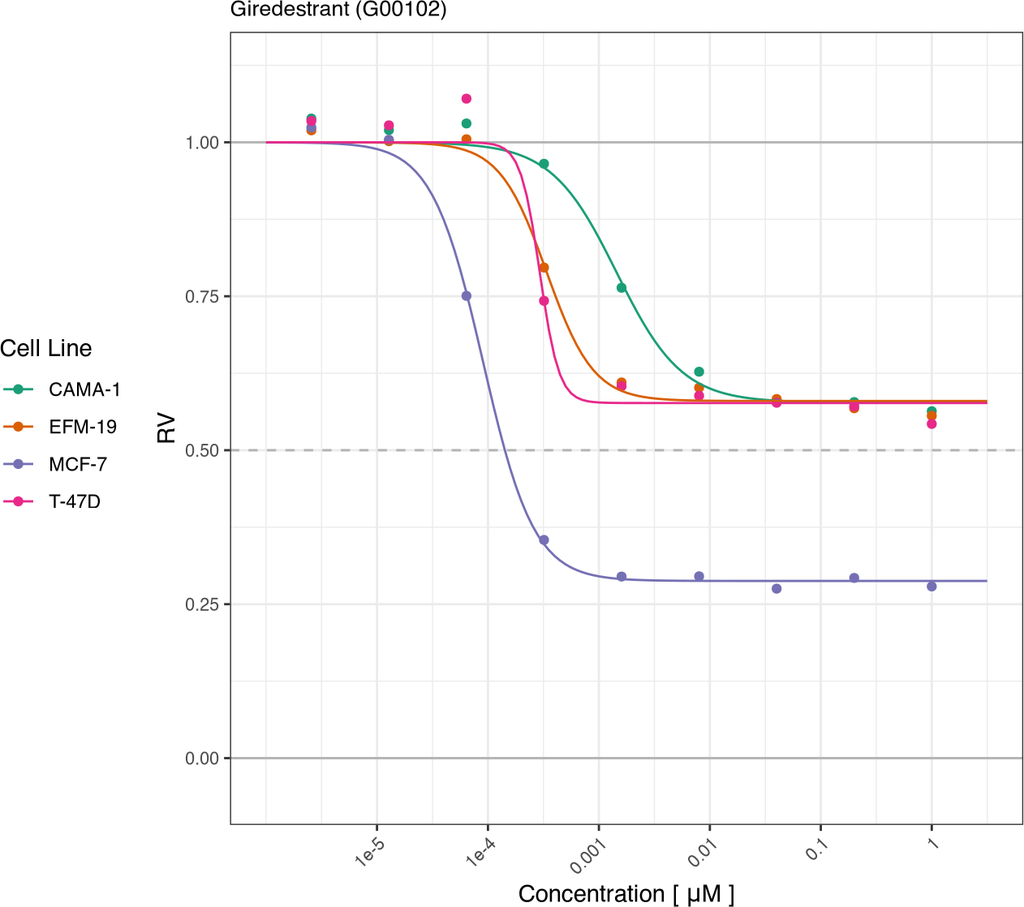

#### 5.1.1.3 Inavolisib

🔍 Zoom In for Details

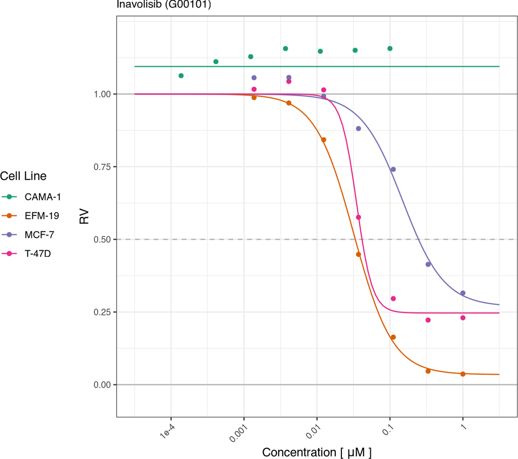

### 5.1.2 GR Value

#### 5.1.2.1 Everolimus

🔍 Zoom In for Details

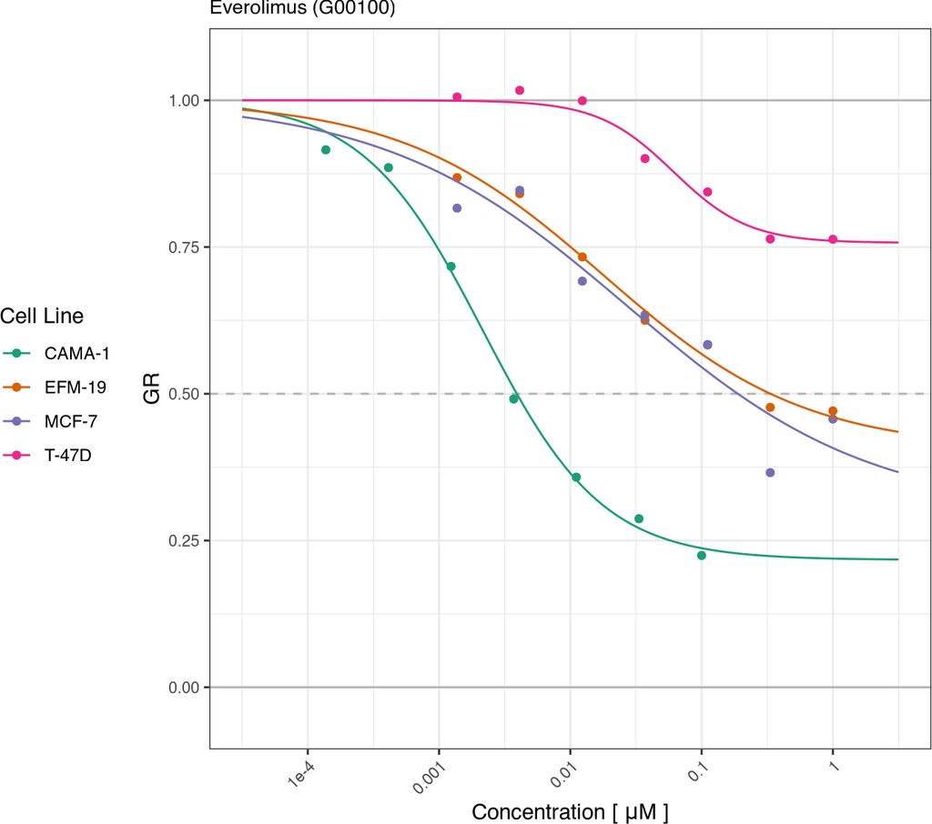

#### 5.1.2.2 Giredestrant

🔍 Zoom In for Details

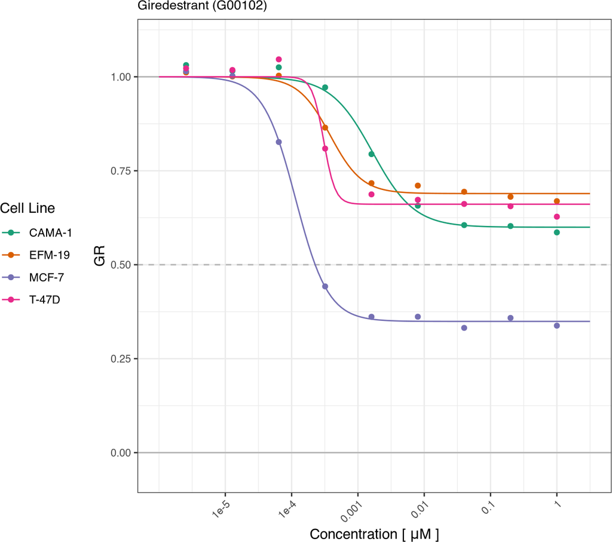

#### 5.1.2.3 Inavolisib

🔍 Zoom In for Details

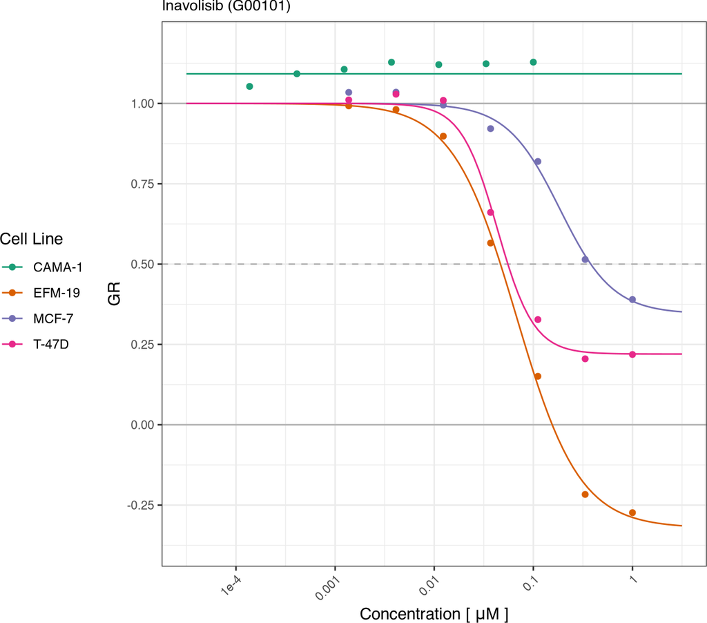

## 5.2 Data Analysis - Dose-response Curves by Cell Lines - Single-Agent Data

Here, each plot displays a single **cell line** tested against all **drugs**. This format is useful for understanding the sensitivity profile of a particular cell line and identifying its vulnerabilities.

**What to look for:** Compare the different colored curves to see which drugs are most potent or effective against this specific cell line.

```r
cellline_name_vec <- sort(unique(response_metrics_sa[["CellLineName"]]))
drug_name_vec <- sort(unique(response_metrics_sa[["DrugName"]]))

ls_curv_RV <- plot_dose_response_sa_by_drugs(dt_metrics = response_metrics_sa,
                                             dt_average = response_data_sa,
                                             cellline_name_vec = cellline_name_vec,
                                             drug_name_vec = drug_name_vec,
                                             normalization_type = "RV")
names(ls_curv_RV) <- vapply(names(ls_curv_RV), function(i) escape_special_characters(i),
                            FUN.VALUE = character(1), USE.NAMES = FALSE)
```

```r
ls_curv_GR <- plot_dose_response_sa_by_drugs(dt_metrics = response_metrics_sa,
                                             dt_average = response_data_sa,
                                             cellline_name_vec = cellline_name_vec,
                                             drug_name_vec = drug_name_vec,
                                             normalization_type = "GR")
names(ls_curv_GR) <- vapply(names(ls_curv_GR), function(i) escape_special_characters(i),
                            FUN.VALUE = character(1), USE.NAMES = FALSE)
```

### 5.2.1 Relative Viability

#### 5.2.1.1 CAMA-1

🔍 Zoom In for Details

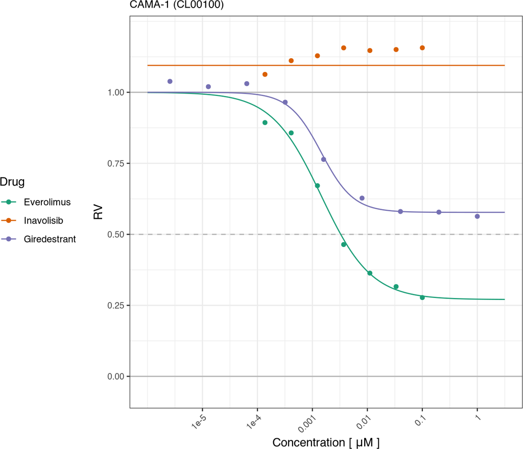

#### 5.2.1.2 EFM-19

🔍 Zoom In for Details

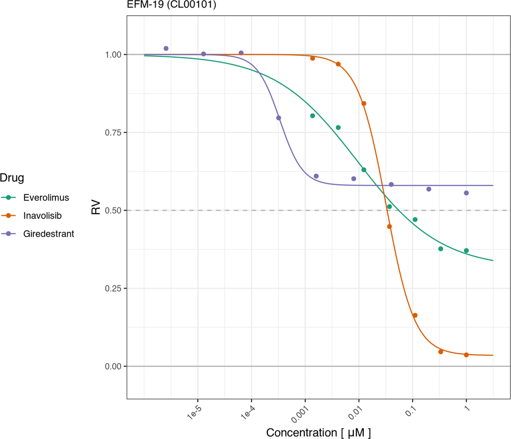

#### 5.2.1.3 MCF-7

🔍 Zoom In for Details

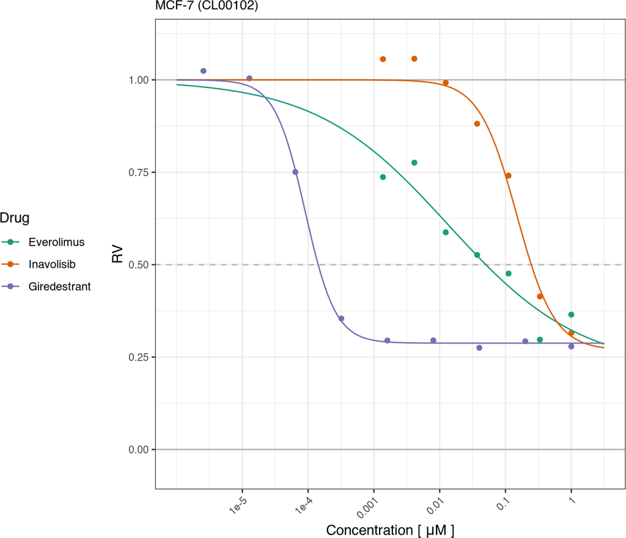

#### 5.2.1.4 T-47D

🔍 Zoom In for Details

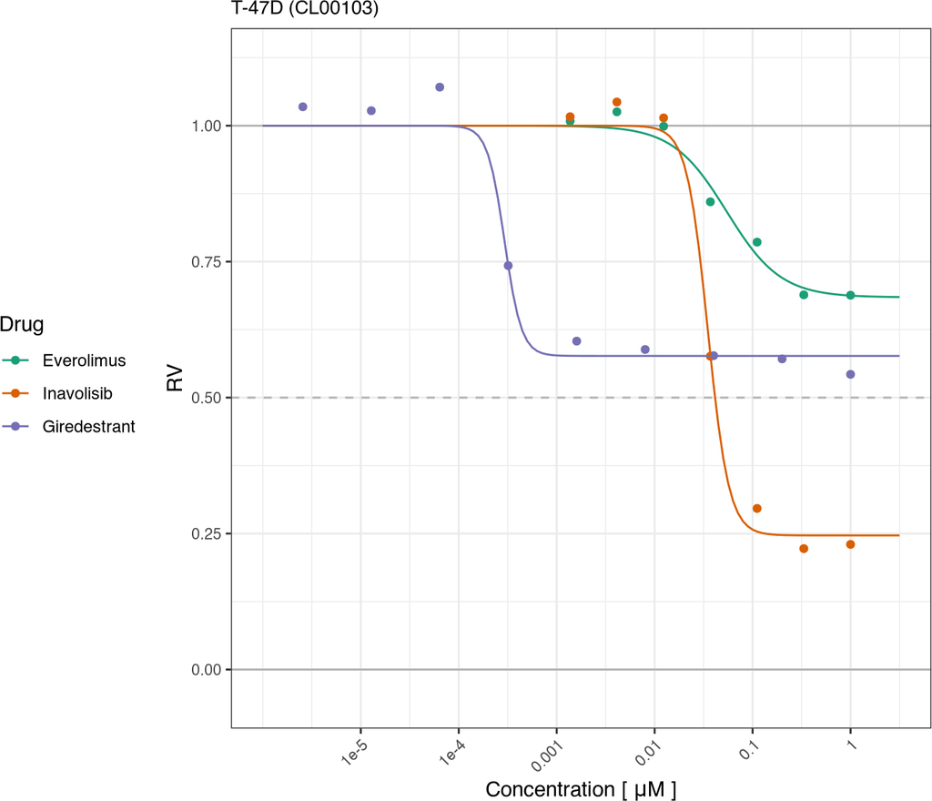

### 5.2.2 GR Value

#### 5.2.2.1 CAMA-1

🔍 Zoom In for Details

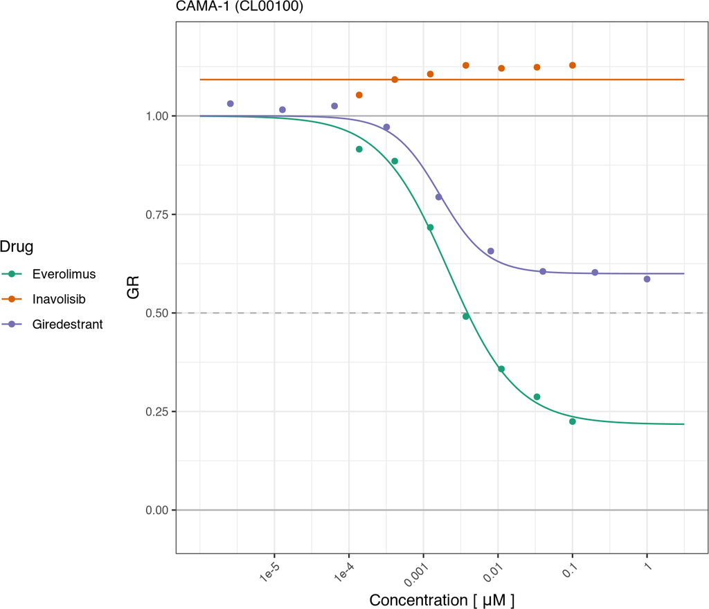

#### 5.2.2.2 EFM-19

🔍 Zoom In for Details

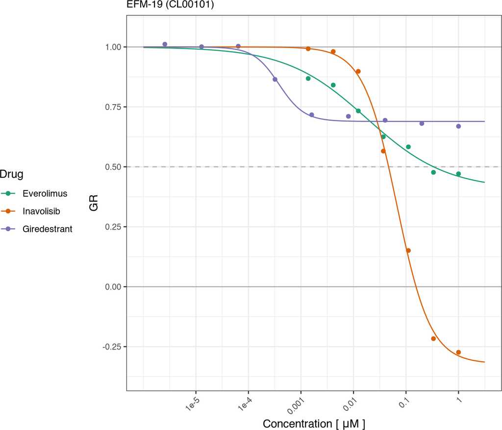

#### 5.2.2.3 MCF-7

🔍 Zoom In for Details

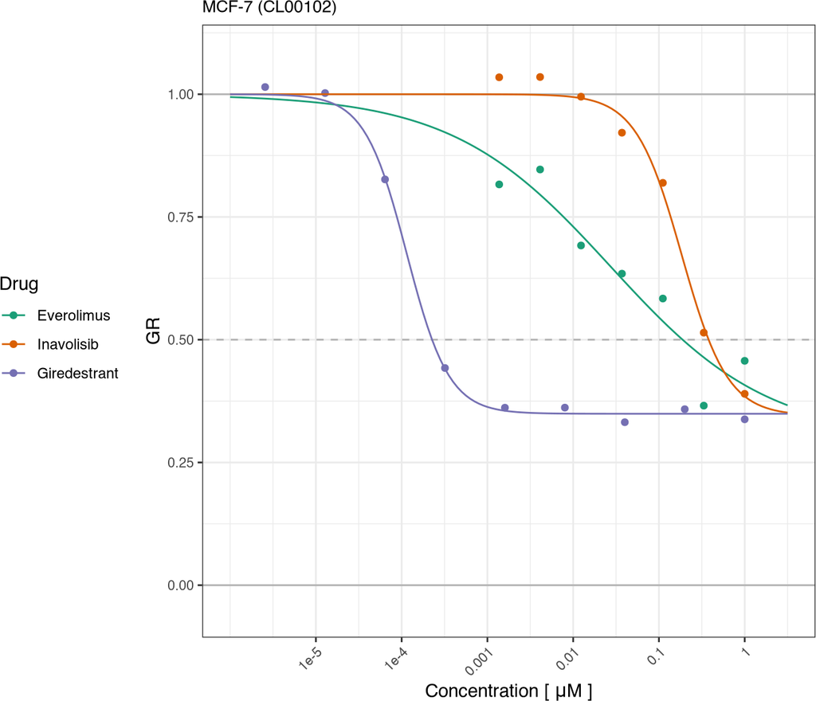

#### 5.2.2.4 T-47D

🔍 Zoom In for Details

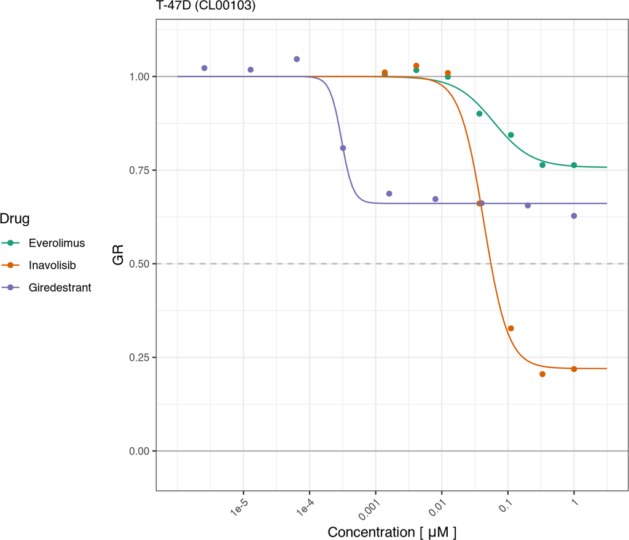

## 5.3 Data Analysis of Fitted Metrics - Single-Agent Data

The following plots summarize the key metrics calculated from the curve fits (e.g., IC50, GR_AOC). They provide a high-level, global overview of the drug response landscape.

### 5.3.1 Heatmaps

The heatmaps display a selected metric for every drug (row) against every cell line (column). Rows and columns are clustered to group similar response profiles.

**What to look for:** Look for ‘hot’ or ‘cold’ blocks, which indicate groups of cell lines that are particularly sensitive or resistant to a group of drugs. The annotations for tissue type or drug MOA can help in interpreting these clusters.

```r
# metrics
metrics <- data.table(
  expand.grid(normalization_type = c("GR", "RV"),
              metric = c("xc50", "x_max", "x_mean", "x_AOC", "x_AOC_range"),
              stringsAsFactors = FALSE))
metrics$hm_title <- pmap(metrics, get_hm_title)

annotation_manual_col <-
  unique(response_metrics_sa[,.SD, .SDcols = c("CellLineName", "Tissue")])
annotation_manual_row <-
  unique(response_metrics_sa[,.SD, .SDcols = c("DrugName", "drug_moa")])
annotation_map <- get_ann_color_map(unique(response_metrics_sa[,.SD, .SDcols = c("Tissue", "drug_moa")]))

ls_plt_RV <- pmap(metrics[normalization_type == "RV", ],
                  pheatmap_with_anno_sa,
                  dt_metrics = response_metrics_sa,
                  dt_metrics_capped = response_metrics_sa_capped,
                  annotation_row = annotation_manual_row,
                  annotation_col = annotation_manual_col,
                  annotation_colors = annotation_map)
names(ls_plt_RV) <- metrics[normalization_type == "RV", ]$hm_title
```

```r
ls_plt_GR <- pmap(metrics[normalization_type == "GR", ],
                  pheatmap_with_anno_sa,
                  dt_metrics = response_metrics_sa,
                  dt_metrics_capped = response_metrics_sa_capped,
                  annotation_row = annotation_manual_row,
                  annotation_col = annotation_manual_col,
                  annotation_colors = annotation_map)
names(ls_plt_GR) <- metrics[normalization_type == "GR", ]$hm_title
```

#### 5.3.1.1 Relative Viability

##### 5.3.1.1.1 log10(IC50)

🔍 Zoom In for Details

💾 Download Table

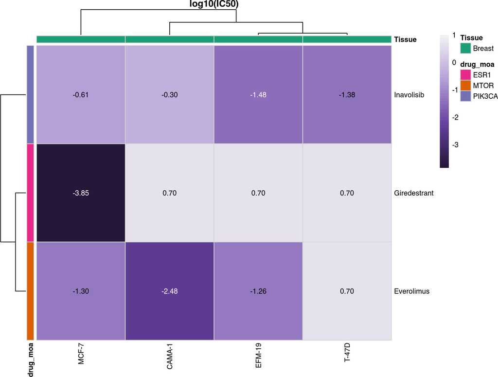